# Producing figures of the 1D 5-cluster model

Sangwon Hyun, Mattias Rolf Cape, Francois Ribalet, Jacob Bien

2022-04-20

# Setup

This script uses the flowmix package from github repository commit number `206aa0575ea2df56f168f42dc335acf002aed458` (https://github.com/sangwon-hyun/flowmix/commit/206aa0575ea2df56f168f42dc335acf002aed458).

# 1d 5-cluster model results

This section contains code to produce the plots for the 1d data 5-cluster analysis in the paper (Figure 7, 12, 13, and Table 2).

First, run the simulations from `gradients2-run.R`, into a destination directory `destin`. Then, use this code to summarize the results.

This will save the summary of the results into `file.path(destin, "summary.RDS")`.

In this script, I’m loading this file directly, from `./paper-data/1d-cvres.rds`

```r
## Load the summary
## cvres = readRDS(file = file.path(destin, "summary.RDS"))

## Instead, load this summary
cvres_filename = "1d-cvres.rds"
cvres = readRDS(file = file.path(datadir, cvres_filename))

## For back-compatibility; prob was called pie
cvres$bestres$prob = cvres$bestres$pie
class(cvres$bestres) = "flowmix"
```

We’ll also load the 1d data from the directory `../paper-data`. (Normally, the data is saved to `file.path(destin, "meta.Rdata")`)

```r
## load(file.path(cvres$destin, "meta.Rdata")) ## This is one way to load the data
dat = readRDS(file = file.path("../paper-data", "MGL1704-hourly-paper-1d-diam.RDS"))
countslist = dat$countslist
ylist = dat$ylist
```

## Figure 12

Figure 12 is produced using this code:

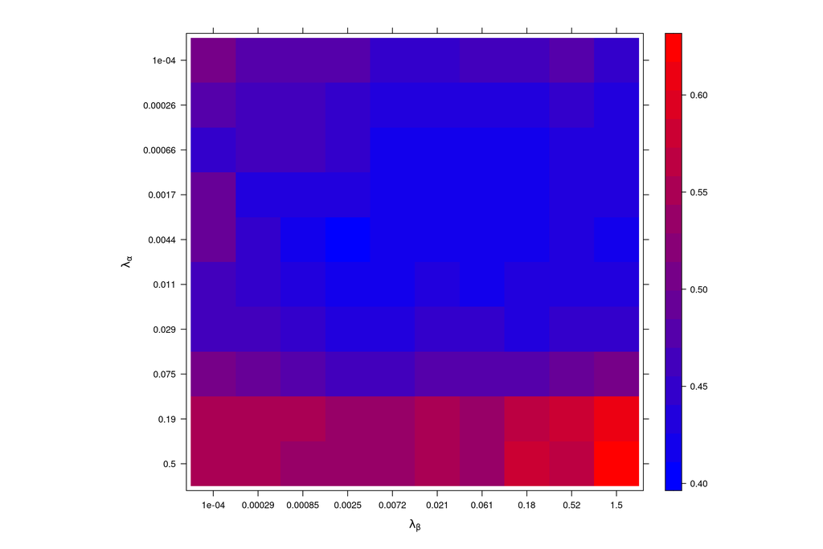

```r
## Plot CV scores
## pdf(file = file.path(figdir, "1d-cvscores.pdf"), width=12, height=5)
plot_cvscore(cvres$cvscore.mat)
```

```r
## graphics.off()
```

## Figure 7

Figure 7 is produced using this code:

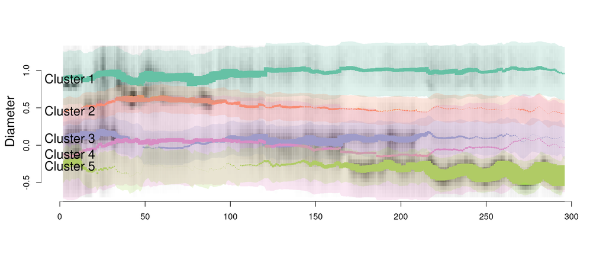

```r
## Plot fitted mean.
## pdf(file = file.path(figdir, "1d-means.pdf"), width=12, height=5)
plot_1d(ylist = ylist, countslist = countslist,
        res = cvres$bestres,
        cex_data = 1) %>%  invisible()
mtext("Diameter", side = 2, line = 2.5, cex = 1.5)
```

```r
## graphics.off()
```

## Table 2

Table 2 can be produced using this code:

```r
cvres$bestres$alpha %>% t() %>% round(3) %>% as.matrix() %>% knitr::kable() %>% print() ##%>%  xtable::xtable(digits=digits)
```

|  | clust-1 | clust-2 | clust-3 | clust-4 | clust-5 |
| --- | --- | --- | --- | --- | --- |
| intp | -1.345 | -1.757 | -2.421 | -1.854 | -2.062 |
| b1 | 0.000 | 0.000 | 0.000 | 0.000 | 0.000 |
| b2 | 0.000 | 0.000 | 0.000 | 0.000 | 0.000 |
| p1 | 0.000 | 0.000 | 0.000 | 0.000 | 0.000 |
| p2 | 0.000 | -0.005 | -0.231 | 0.006 | 0.000 |
| p3 | 0.000 | 0.000 | -0.007 | 0.000 | 0.000 |
| p4 | 0.000 | 0.000 | 0.000 | 0.000 | 0.000 |
| sss | 0.000 | 0.000 | 0.000 | 0.000 | 0.000 |
| sst | 0.000 | 0.000 | 0.000 | 0.913 | 0.000 |
| Fe | 0.000 | 0.000 | 0.000 | 0.000 | 0.000 |
| PP | 0.000 | 0.088 | 0.000 | 0.000 | 0.000 |
| Si | 0.000 | 0.000 | 0.000 | 0.000 | 0.000 |
| NO3 | 0.000 | 0.000 | 0.000 | 0.000 | 0.000 |
| CHL | 0.000 | 0.000 | 0.134 | -0.045 | 0.000 |
| PHYC | 0.000 | 0.000 | 0.000 | 0.000 | 0.000 |
| PO4 | 0.000 | 0.000 | 0.000 | 0.000 | 0.000 |
| O2 | 0.000 | 0.000 | 0.000 | -0.057 | 0.000 |
| vgosa | 0.000 | -0.116 | 0.000 | 0.000 | 0.000 |
| vgos | 0.133 | 0.000 | 0.000 | 0.000 | 0.000 |
| sla | 0.000 | 0.000 | 0.185 | 0.000 | 0.000 |
| ugosa | 0.000 | 0.000 | 0.000 | 0.000 | 0.000 |
| ugos | 0.000 | 0.022 | -0.134 | -0.086 | 0.000 |
| wind_stress | 0.000 | 0.000 | 0.000 | 0.000 | 0.011 |
| eastward_wind | 0.000 | 0.000 | 0.000 | 0.000 | 0.000 |
| surface_downward_eastward_stress | 0.000 | 0.000 | 0.000 | 0.000 | 0.000 |
| wind_speed | 0.000 | 0.000 | 0.000 | -0.165 | 0.000 |
| surface_downward_northward_stress | 0.000 | 0.000 | 0.000 | 0.000 | 0.000 |
| northward_wind | 0.138 | 0.000 | 0.000 | -0.063 | 0.000 |
| ftle_bw_sla | 0.032 | -0.094 | 0.000 | 0.000 | 0.000 |
| disp_bw_sla | 0.000 | 0.000 | 0.000 | 0.018 | 0.000 |
| AOU_WOA_clim | 0.000 | 0.000 | 0.000 | 0.000 | 0.000 |
| density_WOA_clim | 0.000 | 0.000 | 0.000 | 0.000 | 0.000 |
| o2sat_WOA_clim | 0.000 | 0.280 | 0.000 | 0.000 | 0.000 |
| oxygen_WOA_clim | 0.000 | 0.000 | 0.000 | 0.000 | 0.000 |
| salinity_WOA_clim | 0.000 | 0.000 | 0.000 | 0.000 | 0.000 |
| conductivity_WOA_clim | 0.000 | 0.000 | 0.000 | 0.000 | 0.000 |
| nitrate_WOA_clim | 0.000 | -0.636 | 0.000 | 0.000 | 0.000 |
| phosphate_WOA_clim | 0.000 | 0.000 | 0.158 | -0.860 | 0.000 |
| silicate_WOA_clim | -0.015 | 0.000 | 0.000 | 0.000 | 0.000 |
| par | 0.018 | 0.000 | 0.000 | -0.027 | 0.000 |

```r
cvres$bestres$beta  %>% setNames(paste0("Cluster-", 1:5)) %>% do.call(cbind, .) %>% `colnames<-`(paste0("Cluster-", 1:5)) %>%
  round(3) %>% as.matrix() %>% knitr::kable() %>% print()##%>%  xtable::xtable(digits=digits)
```

|  | Cluster-1 | Cluster-2 | Cluster-3 | Cluster-4 | Cluster-5 |
| --- | --- | --- | --- | --- | --- |
| intp | 0.914 | 0.082 | 0.516 | -0.326 | -0.033 |
| b1 | 0.014 | 0.032 | 0.000 | 0.046 | 0.038 |
| b2 | 0.077 | -0.023 | 0.000 | 0.000 | 0.000 |
| p1 | 0.002 | 0.000 | 0.004 | 0.008 | -0.002 |
| p2 | 0.000 | 0.006 | -0.004 | 0.013 | -0.006 |
| p3 | 0.007 | 0.005 | 0.000 | 0.010 | -0.003 |
| p4 | -0.004 | 0.002 | 0.010 | -0.006 | -0.002 |
| sss | 0.000 | 0.000 | 0.000 | -0.067 | 0.000 |
| sst | 0.000 | -0.004 | -0.028 | -0.070 | 0.000 |
| Fe | 0.000 | -0.011 | 0.000 | 0.001 | 0.000 |
| PP | 0.066 | -0.008 | 0.000 | 0.000 | 0.000 |
| Si | 0.014 | 0.000 | -0.021 | -0.006 | 0.000 |
| NO3 | 0.000 | 0.000 | 0.000 | 0.000 | 0.000 |
| CHL | -0.141 | 0.000 | 0.000 | 0.000 | 0.000 |
| PHYC | 0.000 | 0.000 | 0.000 | 0.010 | 0.000 |
| PO4 | 0.024 | -0.001 | 0.000 | 0.000 | 0.000 |
| O2 | 0.071 | 0.000 | 0.000 | 0.000 | 0.000 |
| vgosa | 0.000 | 0.000 | 0.014 | 0.000 | 0.025 |
| vgos | 0.012 | 0.000 | 0.000 | -0.006 | 0.000 |
| sla | 0.004 | 0.001 | -0.012 | -0.022 | 0.002 |
| ugosa | 0.000 | -0.005 | 0.000 | -0.050 | 0.007 |
| ugos | 0.005 | 0.000 | 0.007 | 0.058 | 0.000 |
| wind_stress | 0.011 | -0.029 | 0.000 | 0.025 | 0.000 |
| eastward_wind | -0.023 | -0.020 | 0.000 | 0.021 | 0.000 |
| surface_downward_eastward_stress | 0.000 | -0.010 | 0.000 | 0.000 | 0.000 |
| wind_speed | 0.000 | 0.000 | 0.000 | 0.000 | 0.033 |
| surface_downward_northward_stress | 0.000 | 0.000 | -0.002 | 0.011 | -0.007 |
| northward_wind | 0.000 | -0.008 | -0.009 | 0.000 | 0.000 |
| ftle_bw_sla | 0.005 | 0.024 | 0.000 | -0.011 | 0.000 |
| disp_bw_sla | 0.001 | 0.004 | 0.000 | -0.003 | 0.000 |
| AOU_WOA_clim | 0.000 | 0.000 | 0.000 | 0.000 | 0.000 |
| density_WOA_clim | 0.000 | 0.000 | 0.026 | -0.038 | 0.051 |
| o2sat_WOA_clim | 0.010 | 0.017 | -0.004 | -0.022 | 0.000 |
| oxygen_WOA_clim | 0.000 | 0.000 | 0.000 | 0.000 | 0.000 |
| salinity_WOA_clim | 0.000 | 0.000 | 0.000 | 0.000 | 0.000 |
| conductivity_WOA_clim | 0.000 | 0.000 | 0.000 | 0.000 | 0.000 |
| nitrate_WOA_clim | 0.000 | 0.000 | 0.000 | 0.000 | 0.000 |
| phosphate_WOA_clim | 0.000 | 0.000 | 0.052 | -0.132 | 0.012 |
| silicate_WOA_clim | -0.016 | 0.000 | -0.022 | -0.001 | -0.045 |
| par | 0.002 | 0.004 | 0.000 | 0.002 | -0.002 |

## Figure 11

Figure 11 can be produced using this code:

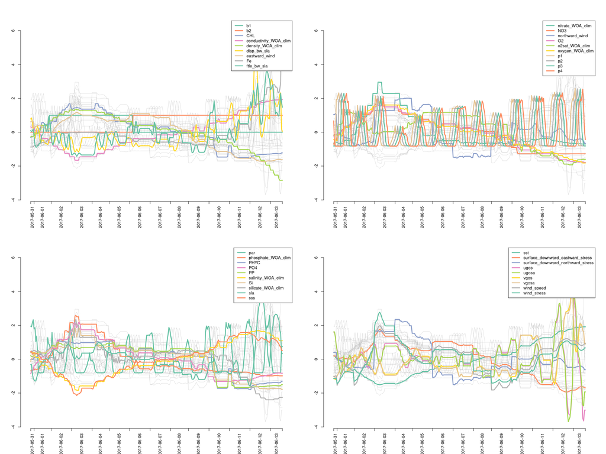

```r
mats = list(alpha = cvres$bestres$alpha, beta = cvres$bestres$beta)

## Plot covariates
allnames = unique(c(colnames(mats$alpha), rownames(mats$beta[[1]])))
allnames = allnames[-which(allnames == "intp")]
Xsmall = cvres$bestres$X %>% as_tibble %>% select(one_of(allnames)) %>% select(sort(names(.)))
inds = round(seq(from = 1, to = ncol(Xsmall), length=5))

##' Make ticks from rownames of res$X (only for 1d data).
##' @param res Object of class |flowmix|.
add_date_ticks <- function(res){
  dates = sapply(as.Date(rownames(res$X)),
                 toString)

  nums = as.numeric(as.factor(dates))
  left_ticks = sapply(sort(unique(nums)),function(ii){min(which(nums==ii))})
  left_ticks = c(left_ticks, res$TT)
  mid_ticks = sapply(sort(unique(nums)),function(ii){mean(which(nums==ii))})
  dates_mid_ticks = dates[round(mid_ticks)]
  axis(1, at=left_ticks, labels=FALSE)
  axis(1, at=mid_ticks, labels = dates_mid_ticks, tick=FALSE, las=2)
  axis(2)
}


## pdf(file = file.path(figdir, "1d-covariates.pdf"), width=20, height=15)
par(mfrow=c(2,2))
for(ii in 1:4){
  ind = (inds[ii]+1):inds[ii+1]
  cols = RColorBrewer::brewer.pal(length(ind), "Set2")
  matplot(Xsmall, axes=FALSE, col='grey', type='l', lwd=.5, lty=1, ylab="",xlab="")
  add_date_ticks(cvres$bestres)
  matlines(Xsmall[,ind], col=cols, lwd=3, lty=1)
  legend("topright", col=cols, lwd=3, lty=1, legend = colnames(Xsmall)[ind])
}
```

```r
## graphics.off()
```

## Figure 13

Figure 13 is produced using the second block (starting with `# A 5 x 5 version of this`):

```r
load(file.path(cvres$destin, "meta.Rdata")) ## load ylist
## png(file=file.path(figdir, "1d-all-models.png"), width=5000, height=4000)
cv_gridsize = 10
par(mfrow = c(cv_gridsize, cv_gridsize))
for(ialpha in 1:cv_gridsize){
  for(ibeta in 1:cv_gridsize){
    res = cvres$bestreslist[[paste0(ialpha, "-", ibeta)]]
    res$prob = res$pie ## For back-compatibility; prob was called pie
    plot_1d(ylist = ylist, countslist = countslist, res = res,
            cex_data = 1)
    title(main = c(paste0("in-sample: ", round(min(res$objective),3)), "   ",
                   paste0("CV score : ", round(cvres$cvscore.mat[ialpha,ibeta],3))),
          cex.main=3)
    if(all(c(ialpha, ibeta) == cvres$min.ind)) box(lwd=10,col='blue')
  }
}
## graphics.off()

## A 5 x 5 version of this.
load(file.path(cvres$destin, "meta.Rdata")) ## load ylist
## png(file=file.path(figdir, "1d-all-models-reduced.png"), width=5000/2, height=3000/2)
cv_gridsize = 10
par(mfrow = c(cv_gridsize/2, cv_gridsize/2 ))
par(mar=c(0,0,5,0))
for(ialpha in c(1,3,5,7,10)){
  for(ibeta in c(1,4,6,8,10)){
    print(c(ialpha, ibeta))
    res = cvres$bestreslist[[paste0(ialpha, "-", ibeta)]]
    res$prob = res$pie ## For back-compatibility; prob was called pie
    plot_1d(ylist = ylist, countslist = countslist, res = res,
            no_axis=TRUE, cex_clust_label=NULL, omit_label=TRUE,
            omit_band=TRUE,
            cex_data = 1.7)
    title(main = c(paste0("In-sample: ", round(min(res$objective),3)), "   ",
                   paste0("CV score : ", round(cvres$cvscore.mat[ialpha,ibeta],3))),
          cex.main=4)##3.5)
    if(all(c(ialpha, ibeta) == cvres$min.ind)) box(lwd=10,col='blue')
  }
}
## graphics.off()
```

# 3d 10-cluster model results

```r
### Load the model
cvres_filename = paste0("cvres-", paste0(2,"-", 64,"-", 10), ".Rdata")

### cvres = blockcv_summary(2, 64, 10, 7, nrep = 5)

### save(cvres, file = file.path(datadir, cvres_filename))

load(file = file.path(datadir, cvres_filename), verbose = FALSE)
res = cvres$bestres
destin = cvres$destin

## Quick adjustments, for back-compatibility
class(res) = "flowmix" ## for back-compatibility
res$prob = res$pie ## for back-compatibility
```

## Table 3,4,5,6

Table 3,4,5,6 are produced using this code:

```r
for(iclust in 1:10){
  onebeta = res$beta[[iclust]]
  colnames(onebeta) = c("diam", "red", "orange")
  knitr::kable(onebeta, digits=10, caption = paste0("Beta coefficientns for Cluster ", iclust)) %>% print()
}
```

Beta coefficientns for Cluster 1

|  | diam | red | orange |
| --- | --- | --- | --- |
| intp | 5.968095531 | 4.259373072 | 7.312468609 |
| b1 | 0.000000000 | 0.000000000 | 0.000000000 |
| b2 | 0.000000000 | 0.000000000 | 0.000000000 |
| p1 | 0.000000000 | 0.088480468 | 0.000000000 |
| p2 | 0.003237397 | 0.000000000 | 0.000000000 |
| p3 | 0.002195150 | 0.004950264 | -0.005398967 |
| p4 | 0.000000000 | -0.012164948 | 0.023084113 |
| sss | 0.000000000 | 0.000000000 | 0.000000000 |
| sst | 0.000000000 | 0.000000000 | 0.000000000 |
| Fe | 0.000000000 | 0.000000000 | 0.000000000 |
| PP | 0.000000000 | 0.000000000 | 0.000000000 |
| Si | 0.000000000 | 0.000000000 | 0.000000000 |
| NO3 | 0.000000000 | 0.000000000 | 0.000000000 |
| CHL | 0.000000000 | 0.000000000 | 0.000000000 |
| PHYC | 0.000000000 | 0.000000000 | 0.000000000 |
| PO4 | 0.000000000 | 0.000000000 | 0.000000000 |
| O2 | 0.000000000 | 0.000000000 | 0.000000000 |
| vgosa | 0.000000000 | 0.000000000 | 0.000000000 |
| vgos | 0.000000000 | 0.000000000 | 0.000000000 |
| sla | 0.000000000 | -0.001524180 | 0.025666353 |
| ugosa | 0.000000000 | -0.044216683 | 0.000000000 |
| ugos | 0.000000000 | 0.000000000 | 0.000000000 |
| wind_stress | 0.000000000 | 0.000000000 | 0.000000000 |
| eastward_wind | 0.000000000 | 0.000000000 | 0.000000000 |
| surface_downward_eastward_stress | 0.000000000 | 0.000000000 | 0.000000000 |
| wind_speed | 0.000000000 | 0.000000000 | 0.000000000 |
| surface_downward_northward_stress | 0.000000000 | 0.000000000 | 0.000000000 |
| northward_wind | 0.000000000 | 0.000000000 | 0.000000000 |
| ftle_bw_sla | 0.000000000 | 0.000000000 | 0.000000000 |
| disp_bw_sla | 0.000000000 | 0.000000000 | 0.000000000 |
| AOU_WOA_clim | 0.000000000 | 0.000000000 | 0.000000000 |
| density_WOA_clim | 0.000000000 | 0.000000000 | 0.000000000 |
| o2sat_WOA_clim | 0.000000000 | 0.000000000 | 0.000000000 |
| oxygen_WOA_clim | 0.000000000 | 0.000000000 | 0.000000000 |
| salinity_WOA_clim | 0.000000000 | 0.000000000 | 0.000000000 |
| conductivity_WOA_clim | 0.000000000 | 0.000000000 | 0.000000000 |
| nitrate_WOA_clim | 0.000000000 | 0.000000000 | 0.000000000 |
| phosphate_WOA_clim | 0.000000000 | 0.000000000 | 0.000000000 |
| silicate_WOA_clim | 0.000000000 | 0.000000000 | 0.000000000 |
| par | 0.000000000 | 0.000000000 | 0.000000000 |

Beta coefficientns for Cluster 2

|  | diam | red | orange |
| --- | --- | --- | --- |
| intp | 5.9284345966 | 4.85418418 | 2.81943125 |
| b1 | 0.0000000000 | 0.00000000 | 0.00000000 |
| b2 | 0.0000000000 | 0.00000000 | 0.00000000 |
| p1 | -0.0001051634 | 0.00000000 | 0.00000000 |
| p2 | 0.0000000000 | 0.00000000 | 0.00000000 |
| p3 | 0.0000000000 | 0.00000000 | 0.00000000 |
| p4 | 0.0000000000 | 0.00000000 | 0.00000000 |
| sss | 0.0000000000 | 0.00000000 | 0.00000000 |
| sst | 0.0000000000 | 0.00000000 | 0.00000000 |
| Fe | 0.0000000000 | 0.00000000 | 0.07211896 |
| PP | 0.0000000000 | 0.00000000 | 0.00000000 |
| Si | 0.0000000000 | 0.00000000 | 0.00000000 |
| NO3 | 0.0000000000 | 0.00000000 | 0.00000000 |
| CHL | 0.0000000000 | 0.00000000 | 0.00000000 |
| PHYC | 0.0000000000 | 0.01947219 | 0.00000000 |
| PO4 | 0.0000000000 | 0.03782072 | 0.00000000 |
| O2 | 0.0000000000 | 0.00000000 | 0.00000000 |
| vgosa | 0.0000000000 | 0.00000000 | 0.00000000 |
| vgos | 0.0000000000 | 0.00000000 | 0.00000000 |
| sla | 0.0000000000 | 0.00000000 | 0.04791567 |
| ugosa | 0.0000000000 | 0.00000000 | 0.00000000 |
| ugos | 0.0000000000 | 0.00000000 | 0.00000000 |
| wind_stress | 0.0000000000 | 0.00000000 | 0.00000000 |
| eastward_wind | 0.0000000000 | 0.00000000 | 0.00000000 |
| surface_downward_eastward_stress | 0.0000000000 | 0.00000000 | 0.00000000 |
| wind_speed | 0.0000000000 | 0.00000000 | 0.00000000 |
| surface_downward_northward_stress | 0.0000000000 | 0.00000000 | 0.00000000 |
| northward_wind | 0.0000000000 | 0.00000000 | 0.00000000 |
| ftle_bw_sla | 0.0000000000 | 0.00000000 | 0.00000000 |
| disp_bw_sla | 0.0000000000 | 0.00000000 | 0.00000000 |
| AOU_WOA_clim | 0.0000000000 | 0.00000000 | 0.00000000 |
| density_WOA_clim | 0.0000000000 | 0.00000000 | 0.00000000 |
| o2sat_WOA_clim | -0.0051724217 | 0.00000000 | 0.00000000 |
| oxygen_WOA_clim | 0.0000000000 | 0.00000000 | 0.00000000 |
| salinity_WOA_clim | 0.0000000000 | 0.00000000 | 0.00000000 |
| conductivity_WOA_clim | 0.0000000000 | 0.00000000 | 0.00000000 |
| nitrate_WOA_clim | 0.0000000000 | 0.00000000 | 0.00000000 |
| phosphate_WOA_clim | 0.0000000000 | 0.00000000 | 0.00000000 |
| silicate_WOA_clim | 0.0000000000 | 0.00000000 | -0.01639025 |
| par | 0.0000000000 | 0.00000000 | 0.00000000 |

Beta coefficientns for Cluster 3

|  | diam | red | orange |
| --- | --- | --- | --- |
| intp | 3.053828688 | 2.734432867 | 3.066667492 |
| b1 | 0.000000000 | 0.000000000 | 0.188918929 |
| b2 | -0.030552519 | -0.214914300 | -0.046613588 |
| p1 | 0.028770267 | -0.016449035 | 0.000000000 |
| p2 | 0.033964054 | -0.005357155 | 0.017515021 |
| p3 | 0.039639725 | 0.022252885 | 0.000000000 |
| p4 | 0.000000000 | 0.018108747 | 0.024554493 |
| sss | 0.000000000 | 0.026642658 | 0.000000000 |
| sst | 0.000000000 | 0.000000000 | -0.001066180 |
| Fe | -0.028930710 | 0.000000000 | 0.000000000 |
| PP | 0.000000000 | -0.113621472 | -0.099036941 |
| Si | 0.266369620 | 0.000000000 | 0.000000000 |
| NO3 | 0.000000000 | 0.000000000 | 0.000000000 |
| CHL | -0.137182964 | 0.184773277 | 0.081165090 |
| PHYC | 0.000000000 | 0.000000000 | 0.000000000 |
| PO4 | 0.000000000 | 0.000000000 | 0.000000000 |
| O2 | 0.000000000 | 0.000000000 | 0.034039716 |
| vgosa | 0.000000000 | -0.019974801 | 0.000000000 |
| vgos | 0.043537783 | 0.000000000 | 0.000000000 |
| sla | 0.049054132 | -0.011223886 | 0.014263833 |
| ugosa | 0.000000000 | 0.000000000 | 0.000000000 |
| ugos | -0.073874323 | 0.000000000 | 0.062561257 |
| wind_stress | 0.000000000 | -0.096102928 | -0.056282580 |
| eastward_wind | -0.016324939 | 0.000000000 | 0.000000000 |
| surface_downward_eastward_stress | 0.000000000 | -0.050850935 | 0.000000000 |
| wind_speed | -0.111971670 | 0.077574250 | 0.097343356 |
| surface_downward_northward_stress | 0.021993977 | 0.000000000 | 0.000000000 |
| northward_wind | 0.000000000 | 0.014900891 | -0.001973156 |
| ftle_bw_sla | 0.098820130 | 0.075252460 | 0.006401732 |
| disp_bw_sla | 0.066465241 | 0.000000000 | -0.015352797 |
| AOU_WOA_clim | 0.000000000 | 0.000000000 | -0.168113341 |
| density_WOA_clim | 0.000000000 | 0.000000000 | 0.019794785 |
| o2sat_WOA_clim | 0.001731463 | 0.135285232 | 0.000000000 |
| oxygen_WOA_clim | 0.000000000 | 0.000000000 | 0.000000000 |
| salinity_WOA_clim | 0.000000000 | 0.000000000 | 0.000000000 |
| conductivity_WOA_clim | 0.000000000 | 0.000000000 | 0.000000000 |
| nitrate_WOA_clim | 0.000000000 | -0.017238285 | 0.000000000 |
| phosphate_WOA_clim | 0.000000000 | 0.000000000 | 0.042338449 |
| silicate_WOA_clim | 0.000000000 | 0.000000000 | -0.100771898 |
| par | 0.019632919 | 0.000000000 | 0.039190904 |

Beta coefficientns for Cluster 4

|  | diam | red | orange |
| --- | --- | --- | --- |
| intp | 3.94478275 | 0.800939334 | 0.5510790298 |
| b1 | 0.00000000 | 0.000000000 | 0.0000000000 |
| b2 | 0.00000000 | -0.011203322 | 0.0470913431 |
| p1 | 0.00000000 | 0.000000000 | -0.0051267445 |
| p2 | 0.00000000 | 0.000000000 | -0.0003768198 |
| p3 | 0.00000000 | 0.000000000 | -0.0046129231 |
| p4 | 0.00000000 | 0.000000000 | -0.0049090076 |
| sss | 0.00000000 | 0.000000000 | -0.0199267703 |
| sst | 0.00000000 | 0.000000000 | 0.0000000000 |
| Fe | 0.00000000 | 0.000000000 | 0.0000000000 |
| PP | 0.00000000 | 0.000000000 | 0.0072871711 |
| Si | 0.00000000 | 0.000000000 | 0.0000000000 |
| NO3 | 0.00000000 | 0.000000000 | 0.0000000000 |
| CHL | 0.00000000 | 0.000000000 | 0.0000000000 |
| PHYC | 0.00000000 | 0.000000000 | 0.0000000000 |
| PO4 | 0.00000000 | 0.000000000 | 0.0015115451 |
| O2 | 0.00000000 | 0.000000000 | 0.0000000000 |
| vgosa | 0.00000000 | 0.000000000 | 0.0000000000 |
| vgos | 0.00000000 | 0.000000000 | 0.0000000000 |
| sla | 0.00000000 | 0.000000000 | 0.0000000000 |
| ugosa | 0.00000000 | -0.005928616 | 0.0000000000 |
| ugos | 0.00000000 | 0.000000000 | 0.0000000000 |
| wind_stress | 0.00000000 | 0.000000000 | 0.0000000000 |
| eastward_wind | 0.00000000 | 0.044257257 | 0.0000000000 |
| surface_downward_eastward_stress | 0.00000000 | 0.000000000 | 0.0156934800 |
| wind_speed | 0.08987578 | 0.000000000 | 0.0000000000 |
| surface_downward_northward_stress | 0.00000000 | 0.000000000 | 0.0000000000 |
| northward_wind | 0.00000000 | -0.001137329 | 0.0000000000 |
| ftle_bw_sla | 0.00000000 | 0.000000000 | 0.0000000000 |
| disp_bw_sla | 0.00000000 | 0.000000000 | 0.0000000000 |
| AOU_WOA_clim | 0.00000000 | 0.000000000 | 0.0000000000 |
| density_WOA_clim | 0.00000000 | 0.000000000 | 0.0000000000 |
| o2sat_WOA_clim | 0.00000000 | 0.000000000 | 0.0000000000 |
| oxygen_WOA_clim | 0.00000000 | 0.000000000 | 0.0000000000 |
| salinity_WOA_clim | 0.00000000 | 0.000000000 | 0.0000000000 |
| conductivity_WOA_clim | 0.00000000 | 0.000000000 | 0.0000000000 |
| nitrate_WOA_clim | 0.00000000 | 0.000000000 | 0.0445281005 |
| phosphate_WOA_clim | 0.01330943 | 0.000000000 | 0.0000000000 |
| silicate_WOA_clim | 0.00000000 | 0.000000000 | 0.0000000000 |
| par | 0.00000000 | 0.000000000 | -0.0022121860 |

Beta coefficientns for Cluster 5

|  | diam | red | orange |
| --- | --- | --- | --- |
| intp | 4.986441529 | 5.324611782 | 0.4936000916 |
| b1 | 0.000000000 | 0.000000000 | 0.0056939175 |
| b2 | 0.062266024 | -0.156980029 | 0.0000000000 |
| p1 | 0.000000000 | -0.003904175 | 0.0000000000 |
| p2 | 0.041519223 | -0.001549597 | -0.0020668092 |
| p3 | 0.035577815 | 0.034980200 | -0.0062915949 |
| p4 | 0.000000000 | 0.065074590 | -0.0027824560 |
| sss | 0.000000000 | 0.000000000 | 0.0000000000 |
| sst | 0.000000000 | 0.000000000 | 0.0000000000 |
| Fe | 0.000000000 | 0.000000000 | 0.0000000000 |
| PP | 0.000000000 | -0.395517363 | 0.0000000000 |
| Si | 0.000000000 | 0.000000000 | 0.0000000000 |
| NO3 | 0.000000000 | 0.000000000 | 0.0000000000 |
| CHL | 0.000000000 | 0.214728693 | 0.0389324522 |
| PHYC | 0.000000000 | 0.000000000 | 0.0000000000 |
| PO4 | 0.000000000 | 0.000000000 | 0.0000000000 |
| O2 | 0.000000000 | 0.000000000 | 0.0000000000 |
| vgosa | 0.093737891 | 0.000000000 | 0.0108960904 |
| vgos | 0.000000000 | 0.000000000 | 0.0000000000 |
| sla | 0.000000000 | 0.000000000 | 0.0000000000 |
| ugosa | 0.039513833 | 0.000000000 | 0.0048786632 |
| ugos | 0.000000000 | 0.013910597 | 0.0000000000 |
| wind_stress | 0.000000000 | -0.062007723 | 0.0000000000 |
| eastward_wind | 0.000000000 | 0.000000000 | 0.0184339923 |
| surface_downward_eastward_stress | 0.000000000 | 0.000000000 | 0.0000000000 |
| wind_speed | -0.092006661 | 0.000000000 | 0.0099805389 |
| surface_downward_northward_stress | 0.002308997 | -0.072639723 | 0.0000000000 |
| northward_wind | 0.000000000 | 0.000000000 | 0.0000000000 |
| ftle_bw_sla | 0.000000000 | 0.056271420 | 0.0000000000 |
| disp_bw_sla | 0.000000000 | 0.000000000 | 0.0000000000 |
| AOU_WOA_clim | 0.000000000 | 0.000000000 | 0.0000000000 |
| density_WOA_clim | 0.046191169 | 0.000000000 | 0.0000000000 |
| o2sat_WOA_clim | -0.175196083 | 0.000000000 | -0.0280276234 |
| oxygen_WOA_clim | 0.000000000 | 0.000000000 | 0.0000000000 |
| salinity_WOA_clim | 0.000000000 | 0.000000000 | 0.0000000000 |
| conductivity_WOA_clim | 0.000000000 | 0.000000000 | 0.0000000000 |
| nitrate_WOA_clim | 0.000000000 | 0.048632912 | 0.0000000000 |
| phosphate_WOA_clim | 0.128105135 | 0.096144750 | 0.0275039300 |
| silicate_WOA_clim | 0.000000000 | 0.095391721 | -0.0019678715 |
| par | 0.034601411 | -0.016013761 | 0.0007855167 |

Beta coefficientns for Cluster 6

|  | diam | red | orange |
| --- | --- | --- | --- |
| intp | 3.482483385 | 1.5918171 | 1.532339 |
| b1 | 0.000000000 | 0.0000000 | 0.000000 |
| b2 | 0.000000000 | 0.0000000 | 0.000000 |
| p1 | 0.000000000 | 0.0000000 | 0.000000 |
| p2 | -0.028452219 | 0.0000000 | 0.000000 |
| p3 | 0.000000000 | 0.0000000 | 0.000000 |
| p4 | 0.000000000 | 0.0000000 | 0.000000 |
| sss | 0.000000000 | 0.0000000 | 0.000000 |
| sst | 0.000000000 | 0.0000000 | 0.000000 |
| Fe | 0.000000000 | 0.0000000 | 0.000000 |
| PP | 0.000000000 | 0.0000000 | 0.000000 |
| Si | 0.000000000 | 0.0000000 | 0.000000 |
| NO3 | 0.000000000 | 0.0000000 | 0.000000 |
| CHL | 0.000000000 | 0.0000000 | 0.000000 |
| PHYC | 0.000000000 | 0.0000000 | 0.000000 |
| PO4 | 0.000000000 | 0.0000000 | 0.000000 |
| O2 | 0.000000000 | 0.0000000 | 0.000000 |
| vgosa | 0.071386211 | 0.0000000 | 0.000000 |
| vgos | 0.000000000 | 0.0000000 | 0.000000 |
| sla | 0.002178113 | 0.0000000 | 0.000000 |
| ugosa | 0.000000000 | 0.0000000 | 0.000000 |
| ugos | 0.000000000 | 0.0000000 | 0.000000 |
| wind_stress | 0.000000000 | 0.0000000 | 0.000000 |
| eastward_wind | 0.000000000 | 0.0443385 | 0.000000 |
| surface_downward_eastward_stress | 0.000000000 | 0.0000000 | 0.000000 |
| wind_speed | 0.000000000 | 0.0000000 | 0.000000 |
| surface_downward_northward_stress | 0.000000000 | 0.0000000 | 0.000000 |
| northward_wind | 0.025333431 | 0.0000000 | 0.000000 |
| ftle_bw_sla | 0.000000000 | 0.0000000 | 0.000000 |
| disp_bw_sla | 0.000000000 | 0.0000000 | 0.000000 |
| AOU_WOA_clim | 0.000000000 | 0.0000000 | 0.000000 |
| density_WOA_clim | 0.000000000 | 0.0000000 | 0.000000 |
| o2sat_WOA_clim | 0.000000000 | 0.0000000 | 0.000000 |
| oxygen_WOA_clim | 0.000000000 | 0.0000000 | 0.000000 |
| salinity_WOA_clim | 0.000000000 | 0.0000000 | 0.000000 |
| conductivity_WOA_clim | 0.000000000 | 0.0000000 | 0.000000 |
| nitrate_WOA_clim | 0.004990995 | 0.0000000 | 0.000000 |
| phosphate_WOA_clim | 0.197216611 | 0.0000000 | 0.000000 |
| silicate_WOA_clim | 0.000000000 | 0.0000000 | 0.000000 |
| par | 0.000000000 | 0.0000000 | 0.000000 |

Beta coefficientns for Cluster 7

|  | diam | red | orange |
| --- | --- | --- | --- |
| intp | 6.468244652 | 6.690494715 | 1.457910313 |
| b1 | 0.000000000 | -0.010066972 | 0.000000000 |
| b2 | 0.164754781 | 0.000000000 | 0.039131959 |
| p1 | 0.031037845 | 0.000000000 | 0.000000000 |
| p2 | 0.043703004 | -0.003875314 | -0.005956309 |
| p3 | 0.042477276 | 0.000000000 | -0.000941041 |
| p4 | 0.009046667 | 0.000000000 | -0.011118713 |
| sss | -0.049222368 | 0.000000000 | 0.000000000 |
| sst | 0.000000000 | 0.000000000 | 0.000000000 |
| Fe | 0.000000000 | 0.000000000 | 0.000000000 |
| PP | 0.269983557 | -0.052958459 | 0.022525970 |
| Si | 0.000000000 | 0.030137957 | 0.000000000 |
| NO3 | 0.000000000 | 0.000000000 | 0.000000000 |
| CHL | -0.392623178 | 0.000000000 | 0.000000000 |
| PHYC | 0.000000000 | 0.000000000 | 0.000000000 |
| PO4 | 0.000000000 | 0.000000000 | 0.000000000 |
| O2 | 0.000000000 | 0.000000000 | 0.000000000 |
| vgosa | 0.003715129 | 0.000000000 | 0.000000000 |
| vgos | 0.059892049 | 0.000000000 | 0.000000000 |
| sla | 0.000000000 | -0.039857430 | 0.000000000 |
| ugosa | 0.000000000 | 0.000000000 | 0.000000000 |
| ugos | 0.014007039 | 0.000000000 | 0.000000000 |
| wind_stress | 0.000000000 | 0.002194998 | 0.004492496 |
| eastward_wind | 0.000000000 | 0.000000000 | 0.067508265 |
| surface_downward_eastward_stress | 0.000000000 | 0.014085674 | 0.000000000 |
| wind_speed | -0.021648796 | 0.024419466 | 0.000000000 |
| surface_downward_northward_stress | 0.000000000 | 0.000000000 | 0.000000000 |
| northward_wind | 0.030869437 | -0.018596375 | 0.000000000 |
| ftle_bw_sla | 0.004383963 | 0.000000000 | 0.000000000 |
| disp_bw_sla | 0.006809223 | 0.000000000 | 0.000000000 |
| AOU_WOA_clim | 0.000000000 | 0.000000000 | 0.000000000 |
| density_WOA_clim | 0.000000000 | 0.000000000 | 0.000000000 |
| o2sat_WOA_clim | 0.118108706 | 0.136655866 | 0.000000000 |
| oxygen_WOA_clim | 0.000000000 | 0.000000000 | 0.000000000 |
| salinity_WOA_clim | 0.000000000 | 0.000000000 | 0.000000000 |
| conductivity_WOA_clim | 0.000000000 | 0.000000000 | 0.000000000 |
| nitrate_WOA_clim | -0.008558563 | 0.000000000 | -0.051040858 |
| phosphate_WOA_clim | 0.000000000 | 0.000000000 | 0.000000000 |
| silicate_WOA_clim | -0.032048750 | 0.008768610 | -0.017496671 |
| par | 0.040306274 | -0.015184376 | 0.056219340 |

Beta coefficientns for Cluster 8

|  | diam | red | orange |
| --- | --- | --- | --- |
| intp | 2.067859574 | 0.6553069324 | 0.3586214454 |
| b1 | 0.000000000 | -0.0303536773 | 0.0000000000 |
| b2 | 0.030442408 | -0.0485203544 | 0.0000000000 |
| p1 | -0.016742573 | 0.0121478092 | -0.0015608202 |
| p2 | -0.007582239 | 0.0001740984 | -0.0012395712 |
| p3 | -0.026307710 | 0.0000000000 | -0.0030449855 |
| p4 | -0.006150394 | 0.0000000000 | -0.0004985803 |
| sss | 0.000000000 | 0.0000000000 | 0.0000000000 |
| sst | 0.000000000 | -0.0359499740 | 0.0000000000 |
| Fe | 0.000000000 | 0.0000000000 | 0.0000000000 |
| PP | 0.000000000 | -0.0156779941 | 0.0000000000 |
| Si | -0.009905474 | 0.0000000000 | -0.0015481463 |
| NO3 | 0.000000000 | 0.0000000000 | 0.0000000000 |
| CHL | 0.000000000 | 0.0000000000 | 0.0005304632 |
| PHYC | 0.033957894 | 0.0000000000 | 0.0000000000 |
| PO4 | 0.000000000 | 0.0000000000 | 0.0000000000 |
| O2 | 0.000000000 | 0.0000000000 | 0.0187033314 |
| vgosa | 0.060682121 | 0.0000000000 | 0.0000000000 |
| vgos | 0.000000000 | 0.0019360080 | 0.0020665502 |
| sla | 0.073511978 | -0.0022250961 | 0.0000000000 |
| ugosa | 0.000000000 | 0.0000000000 | 0.0030580396 |
| ugos | 0.034208312 | 0.0000000000 | 0.0000000000 |
| wind_stress | 0.000000000 | -0.0319185848 | 0.0000000000 |
| eastward_wind | 0.113847926 | 0.0098551581 | 0.0113342962 |
| surface_downward_eastward_stress | 0.138645188 | 0.0000000000 | 0.0000000000 |
| wind_speed | 0.135558314 | 0.0432119919 | 0.0052366460 |
| surface_downward_northward_stress | 0.005789204 | 0.0000000000 | 0.0039504788 |
| northward_wind | 0.000000000 | -0.0120681600 | 0.0000000000 |
| ftle_bw_sla | 0.000000000 | 0.0000000000 | 0.0015998364 |
| disp_bw_sla | -0.056236936 | 0.0000000000 | 0.0000000000 |
| AOU_WOA_clim | 0.000000000 | 0.0000000000 | 0.0000000000 |
| density_WOA_clim | 0.030581519 | 0.0000000000 | 0.0000000000 |
| o2sat_WOA_clim | 0.038474202 | 0.0250866785 | -0.0004554307 |
| oxygen_WOA_clim | 0.000000000 | 0.0000000000 | 0.0000000000 |
| salinity_WOA_clim | 0.000000000 | 0.0000000000 | 0.0000000000 |
| conductivity_WOA_clim | 0.000000000 | 0.0000000000 | 0.0000000000 |
| nitrate_WOA_clim | 0.000000000 | 0.0000000000 | 0.0000000000 |
| phosphate_WOA_clim | 0.000000000 | 0.0000000000 | 0.0194514971 |
| silicate_WOA_clim | -0.121452678 | -0.0026934780 | -0.0048742566 |
| par | 0.000000000 | 0.0009309060 | -0.0003262723 |

Beta coefficientns for Cluster 9

|  | diam | red | orange |
| --- | --- | --- | --- |
| intp | 6.890361668 | 1.52187313 | 1.743250242 |
| b1 | 0.000000000 | 0.00000000 | 0.000000000 |
| b2 | 0.000000000 | 0.00000000 | 0.000000000 |
| p1 | 0.000000000 | 0.00000000 | 0.000000000 |
| p2 | 0.000000000 | 0.00000000 | 0.000000000 |
| p3 | 0.000000000 | 0.00000000 | 0.000000000 |
| p4 | 0.000000000 | 0.00000000 | 0.000000000 |
| sss | 0.000000000 | 0.00000000 | -0.006719930 |
| sst | 0.011253357 | 0.00000000 | 0.000000000 |
| Fe | 0.000000000 | -0.01881572 | 0.000000000 |
| PP | 0.000000000 | 0.00000000 | 0.077935649 |
| Si | 0.000000000 | 0.00000000 | 0.000000000 |
| NO3 | 0.000000000 | 0.00000000 | 0.000000000 |
| CHL | 0.000000000 | 0.00000000 | 0.000000000 |
| PHYC | 0.000000000 | 0.00000000 | 0.000000000 |
| PO4 | 0.000000000 | 0.00000000 | 0.000000000 |
| O2 | 0.000000000 | 0.00000000 | 0.000000000 |
| vgosa | 0.000000000 | 0.00000000 | 0.000000000 |
| vgos | 0.000000000 | 0.00000000 | 0.000000000 |
| sla | 0.000000000 | 0.00000000 | 0.000000000 |
| ugosa | 0.000000000 | 0.00000000 | 0.000000000 |
| ugos | 0.000000000 | 0.00000000 | 0.000000000 |
| wind_stress | 0.000000000 | 0.00000000 | 0.000000000 |
| eastward_wind | -0.009923210 | 0.00000000 | 0.000000000 |
| surface_downward_eastward_stress | 0.000000000 | 0.00000000 | 0.000000000 |
| wind_speed | 0.000000000 | 0.00000000 | 0.000000000 |
| surface_downward_northward_stress | 0.000000000 | 0.00000000 | 0.000000000 |
| northward_wind | 0.000000000 | 0.00000000 | 0.000000000 |
| ftle_bw_sla | 0.000000000 | 0.00000000 | 0.000000000 |
| disp_bw_sla | 0.003051813 | -0.01542399 | 0.000000000 |
| AOU_WOA_clim | 0.000000000 | 0.00000000 | 0.000000000 |
| density_WOA_clim | 0.000000000 | 0.00000000 | 0.000000000 |
| o2sat_WOA_clim | -0.046664954 | 0.01486046 | 0.000000000 |
| oxygen_WOA_clim | 0.000000000 | 0.00000000 | 0.000000000 |
| salinity_WOA_clim | 0.000000000 | 0.00000000 | 0.000000000 |
| conductivity_WOA_clim | 0.000000000 | 0.00000000 | 0.000000000 |
| nitrate_WOA_clim | 0.000000000 | 0.00000000 | 0.000000000 |
| phosphate_WOA_clim | 0.000000000 | 0.00000000 | 0.000000000 |
| silicate_WOA_clim | 0.000000000 | 0.02343054 | 0.000000000 |
| par | 0.000000000 | -0.01471873 | -0.006898926 |

Beta coefficientns for Cluster 10

|  | diam | red | orange |
| --- | --- | --- | --- |
| intp | 1.415990835 | 1.362324973 | 0.3568267870 |
| b1 | 0.171902625 | 0.000000000 | 0.0000000000 |
| b2 | 0.049009117 | -0.129168463 | -0.0055911873 |
| p1 | 0.040388261 | -0.019673175 | 0.0008794797 |
| p2 | 0.072969681 | 0.012931907 | 0.0000000000 |
| p3 | 0.022498169 | -0.027850210 | -0.0000365907 |
| p4 | -0.002910622 | 0.000000000 | 0.0000000000 |
| sss | -0.054764821 | 0.000000000 | 0.0000000000 |
| sst | -0.314879406 | 0.000000000 | 0.0000000000 |
| Fe | 0.000000000 | -0.006268936 | 0.0000000000 |
| PP | 0.076559334 | 0.000000000 | 0.0000000000 |
| Si | 0.000000000 | 0.014480287 | 0.0000000000 |
| NO3 | 0.000000000 | 0.000000000 | 0.0000000000 |
| CHL | 0.000000000 | 0.098410546 | 0.0000000000 |
| PHYC | 0.006361228 | 0.000000000 | 0.0000000000 |
| PO4 | 0.000000000 | 0.000000000 | 0.0000000000 |
| O2 | 0.000000000 | 0.000000000 | 0.0000000000 |
| vgosa | 0.000000000 | -0.024449143 | 0.0000000000 |
| vgos | -0.020260243 | 0.000000000 | -0.0003841106 |
| sla | -0.027651693 | -0.013693736 | 0.0000000000 |
| ugosa | -0.046100353 | -0.015591432 | 0.0003389835 |
| ugos | 0.056819468 | 0.000000000 | 0.0000000000 |
| wind_stress | -0.018279871 | 0.000000000 | 0.0000000000 |
| eastward_wind | 0.000000000 | 0.047565529 | 0.0122879348 |
| surface_downward_eastward_stress | -0.028759822 | -0.083413614 | 0.0000000000 |
| wind_speed | 0.000000000 | 0.003169275 | 0.0072140418 |
| surface_downward_northward_stress | 0.000000000 | 0.000000000 | 0.0000000000 |
| northward_wind | 0.001262733 | 0.000000000 | 0.0000000000 |
| ftle_bw_sla | 0.002712154 | -0.020627653 | 0.0000000000 |
| disp_bw_sla | -0.017695401 | -0.007581416 | -0.0006605134 |
| AOU_WOA_clim | 0.000000000 | -0.029385509 | 0.0000000000 |
| density_WOA_clim | -0.060388349 | 0.019958541 | 0.0000000000 |
| o2sat_WOA_clim | -0.040655042 | 0.000000000 | 0.0000000000 |
| oxygen_WOA_clim | 0.000000000 | 0.000000000 | 0.0000000000 |
| salinity_WOA_clim | 0.000000000 | 0.000000000 | -0.0087392612 |
| conductivity_WOA_clim | 0.000000000 | 0.000000000 | 0.0000000000 |
| nitrate_WOA_clim | -0.181959755 | -0.223673418 | 0.0000000000 |
| phosphate_WOA_clim | -0.086413882 | 0.000000000 | 0.0000000000 |
| silicate_WOA_clim | -0.040446198 | -0.003833241 | 0.0000000000 |
| par | 0.024380325 | -0.059013480 | 0.0000000000 |

```r
t(res$alpha) %>%  knitr::kable(digits=10, caption = paste0("Alpha coefficients")) %>% print()
```

Alpha coefficients

|  | clust-1 | clust-2 | clust-3 | clust-4 | clust-5 | clust-6 | clust-7 | clust-8 | clust-9 | clust-10 |
| --- | --- | --- | --- | --- | --- | --- | --- | --- | --- | --- |
| intp | -5.354472250 | -3.13822026 | -2.48933025 | -2.79681799 | -2.37744920 | -3.312255 | -1.85996671 | -1.913991746 | -3.07497797 | -2.30878410 |
| b1 | 0.000000000 | 0.00000000 | 0.00000000 | 0.00000000 | 0.00000000 | 0.000000 | 0.00000000 | 0.000000000 | 0.00000000 | 0.00000000 |
| b2 | 0.000000000 | 0.00000000 | 0.00000000 | 0.00000000 | -0.01726096 | 0.000000 | 0.00000000 | 0.716205823 | 0.00000000 | 0.00000000 |
| p1 | 0.085836335 | 0.00000000 | 0.00000000 | 0.00000000 | 0.00000000 | 0.000000 | 0.00000000 | 0.011783557 | 0.00000000 | 0.00000000 |
| p2 | 0.000000000 | 0.00000000 | 0.00000000 | 0.00000000 | -0.12997729 | 0.000000 | 0.00000000 | 0.000000000 | 0.00000000 | 0.05748439 |
| p3 | 0.000000000 | 0.00000000 | 0.04719697 | 0.00000000 | 0.00000000 | 0.000000 | 0.00000000 | -0.038274581 | 0.00000000 | 0.01806784 |
| p4 | 0.000000000 | 0.00000000 | 0.00000000 | 0.00000000 | 0.00000000 | 0.000000 | 0.00000000 | -0.023251193 | 0.00000000 | 0.00000000 |
| sss | 0.000000000 | 0.00000000 | 0.00000000 | 0.00000000 | 0.00000000 | 0.000000 | 0.00000000 | 0.000000000 | 0.00000000 | 0.02290001 |
| sst | 0.000000000 | 0.00000000 | 0.00000000 | 0.00000000 | 0.00000000 | 0.000000 | 0.00000000 | 0.000000000 | 0.00000000 | 0.86791695 |
| Fe | 0.000000000 | 0.00000000 | 0.00000000 | 0.00000000 | 0.00000000 | 0.000000 | 0.00000000 | 0.000000000 | 0.00000000 | 0.00000000 |
| PP | 0.000000000 | 0.00000000 | 0.19469763 | 0.00000000 | 0.00000000 | 0.000000 | 0.00000000 | 0.000000000 | 0.00000000 | 0.00000000 |
| Si | 0.000000000 | 0.00000000 | 0.00000000 | 0.00000000 | 0.00000000 | 0.000000 | 0.00000000 | 0.000000000 | 0.00000000 | 0.00000000 |
| NO3 | 0.000000000 | 0.00000000 | 0.00000000 | 0.00000000 | 0.00000000 | 0.000000 | 0.00000000 | 0.000000000 | 0.00000000 | 0.00000000 |
| CHL | 0.000000000 | 0.00000000 | 0.00000000 | 0.00000000 | 0.21432808 | 0.000000 | 0.00000000 | 0.000000000 | 0.00000000 | -0.06066823 |
| PHYC | 0.000000000 | 0.00000000 | 0.00000000 | 0.00000000 | 0.00000000 | 0.000000 | 0.00000000 | 0.000000000 | 0.00000000 | 0.00000000 |
| PO4 | 0.000000000 | 0.00000000 | 0.00000000 | 0.00000000 | 0.00000000 | 0.000000 | 0.00000000 | 0.000000000 | 0.00000000 | 0.00000000 |
| O2 | 0.000000000 | 0.00000000 | 0.00000000 | 0.00000000 | 0.00000000 | 0.000000 | 0.00000000 | 0.000000000 | 0.00000000 | 0.00000000 |
| vgosa | 0.000000000 | 0.00000000 | 0.00000000 | 0.00000000 | 0.00000000 | 0.000000 | 0.00000000 | -0.060801105 | 0.00000000 | 0.00000000 |
| vgos | -0.002114332 | 0.00000000 | -0.08849818 | 0.00000000 | 0.00000000 | 0.000000 | 0.07933362 | 0.000000000 | 0.00000000 | 0.00000000 |
| sla | 0.000000000 | 0.02483285 | -0.05579800 | 0.00000000 | 0.20098887 | 0.000000 | 0.00000000 | 0.000000000 | 0.00000000 | 0.00000000 |
| ugosa | 0.000000000 | 0.00000000 | 0.00000000 | 0.00000000 | 0.00000000 | 0.000000 | 0.02540237 | 0.000000000 | 0.00000000 | -0.03350112 |
| ugos | 0.000000000 | 0.00000000 | 0.17528502 | 0.00000000 | -0.18775088 | 0.000000 | 0.00000000 | 0.000000000 | 0.00000000 | -0.06048606 |
| wind_stress | -0.436012754 | 0.03584415 | -0.37055443 | 0.00000000 | -0.08539663 | 0.000000 | 0.00000000 | 0.107894170 | 0.16017099 | 0.00000000 |
| eastward_wind | 0.000000000 | 0.00000000 | 0.00000000 | 0.00000000 | 0.00000000 | 0.000000 | 0.00000000 | 0.000000000 | 0.00000000 | 0.00000000 |
| surface_downward_eastward_stress | 0.000000000 | 0.00000000 | 0.00000000 | 0.00000000 | 0.00000000 | 0.000000 | 0.00000000 | 0.140214981 | 0.00000000 | 0.00000000 |
| wind_speed | 0.000000000 | 0.00000000 | 0.00000000 | 0.00000000 | 0.00000000 | 0.000000 | 0.00000000 | 0.000000000 | 0.00000000 | -0.25457259 |
| surface_downward_northward_stress | 0.000000000 | 0.00000000 | 0.00000000 | 0.00000000 | 0.00000000 | 0.000000 | 0.00000000 | 0.000000000 | 0.00000000 | 0.00000000 |
| northward_wind | 0.000000000 | 0.00000000 | -0.18059294 | 0.00000000 | 0.00000000 | 0.000000 | 0.00000000 | 0.000000000 | 0.01933629 | -0.10500179 |
| ftle_bw_sla | 0.000000000 | 0.00000000 | -0.18030660 | 0.00000000 | 0.00000000 | 0.000000 | 0.00000000 | 0.000000000 | 0.00000000 | 0.00000000 |
| disp_bw_sla | 0.000000000 | 0.00000000 | 0.00000000 | 0.00000000 | -0.16096143 | 0.000000 | 0.00000000 | 0.000000000 | 0.00000000 | 0.01098454 |
| AOU_WOA_clim | 0.000000000 | 0.00000000 | 0.00000000 | 0.03189847 | -0.01966688 | 0.000000 | 0.00000000 | 0.000000000 | 0.00000000 | 0.00000000 |
| density_WOA_clim | 0.000000000 | 0.00000000 | 0.00000000 | 0.00000000 | 0.42886047 | 0.000000 | 0.11105708 | 0.000000000 | 0.00000000 | 0.00000000 |
| o2sat_WOA_clim | 0.000000000 | 0.00000000 | 0.45542258 | -0.04876088 | 0.00000000 | 0.000000 | 0.00000000 | 0.002985964 | -0.14259323 | 0.00000000 |
| oxygen_WOA_clim | 0.000000000 | 0.00000000 | 0.00000000 | 0.00000000 | 0.00000000 | 0.000000 | 0.00000000 | 0.000000000 | 0.00000000 | 0.00000000 |
| salinity_WOA_clim | 0.000000000 | 0.00000000 | 0.00000000 | 0.00000000 | 0.00000000 | 0.000000 | 0.00000000 | 0.000000000 | 0.00000000 | 0.00000000 |
| conductivity_WOA_clim | 0.000000000 | 0.00000000 | 0.00000000 | 0.00000000 | 0.00000000 | 0.000000 | 0.00000000 | 0.000000000 | 0.00000000 | 0.00000000 |
| nitrate_WOA_clim | 0.000000000 | 0.29802627 | -0.34708008 | 0.00000000 | 0.00000000 | 0.000000 | 0.00000000 | -0.005186623 | 0.01487063 | 0.00000000 |
| phosphate_WOA_clim | 0.000000000 | 0.00000000 | 0.00000000 | 0.00000000 | 0.00000000 | 0.000000 | 0.34796662 | 0.000000000 | 0.00000000 | -0.93665103 |
| silicate_WOA_clim | 0.000000000 | 0.00000000 | 0.00000000 | 0.00000000 | 0.00000000 | 0.000000 | 0.00000000 | 0.000000000 | 0.00000000 | 0.00000000 |
| par | 0.431517342 | 0.00000000 | 0.00000000 | 0.00000000 | 0.00000000 | 0.000000 | 0.00000000 | 0.012834378 | 0.00000000 | -0.07906631 |

## Figure 8

Figure 8 is produced using this code:

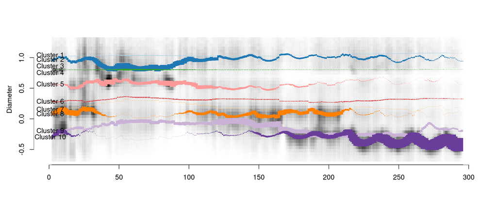

```r
## Rescale diameters (not used anymore since diam in the data is in original
## range, and is shifted/scaled to be in the same scale as CHL and PE only at
## simulation time.)
source("gradients2-helpers.R")

## Temporary *undoing* of the scaling in the estimated model.
range.diam = c(-0.6706111,  1.3070264)
range.chl =  c(0.101313, 7.955767)
range.pe = c(0.101313, 7.955767)

## Modify (rescale/shift) the res$mn
width.diam = range.diam[2] - range.diam[1]
idim = 1
res$mn = res$mn[,idim,, drop=FALSE] / max(range.chl) * width.diam + min(range.diam)

## Undoing the scaling in res$sigma
res$sigma = cvres$bestres$sigma[,idim, idim, drop=FALSE]
myscale = max(range.chl) * width.diam
res$sigma = res$sigma / myscale

## Load the data
datobj = readRDS(file.path(datadir, "MGL1704-hourly-paper-1d-diam.RDS"))
ylist = datobj$ylist
countslist = datobj$countslist

## Make the 1d data+model plot
res$dimdat = 1
cols = plot_1d(ylist = ylist, countslist = countslist, res, scale=TRUE, omit_band=TRUE, omit_label=TRUE)

## Additionally, add y axis label
mtext("Diameter", side=2, line=2.5)

## Additionally, write the cluster numbers with the same colors
res <- reorder_clust(res)
TT = length(ylist)
for(iclust in 1:res$numclust){
  y = res$mn[1, 1, iclust]
  if(iclust==3) y = y + 0.05
  if(iclust==4) y = y - 0.05
  text(x = res$TT/50 - 5, y = y,
       label = paste0("Cluster ", iclust), cex = 1, col="black")##col=cols[iclust])
}
```

It’s worth explaining a bit about data rescaling for Gradients 2. The three dimensions of the original cytogram data (e.g. `MGL1704-hourly-paper.Rdata` or in `MGL1704-hourly.Rdata`) all have a range roughly between 0 and 8, as you can see here:

```r
datobj = readRDS(file = file.path(datadir, "MGL1704-hourly-paper.RDS"))
datobj$ylist[[2]] %>% apply(2, range) %>% knitr::kable() %>% print()
```

| diam_mid | chl_small | pe |
| --- | --- | --- |
| 0.000000 | 0.101313 | 0.101313 |
| 7.955767 | 7.955767 | 7.955767 |

This is the result of shifting and stretching the diameter dimension (the first of the three dimensions), which originally had a range of:

```r
datobj = readRDS(file.path(datadir, "MGL1704-hourly-paper-1d-diam.RDS"));
datobj$ylist[[1]] %>% range() %>% cbind() %>% `colnames<-`(c("diam_mid")) %>% knitr::kable() %>% print()
```

| diam_mid |
| --- |
| -0.6706111 |
| 1.3070264 |

to be the same range as the other two dimensions (Chl and PE), between $0$ and $7.955767$. So the code above is just reversing this shifting and scaling.

## Figure 9

Figure 9 is produced using this code:

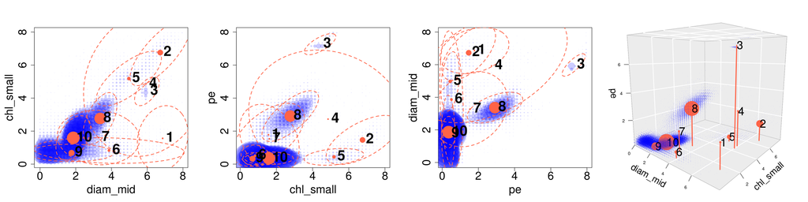

```r
plot_3d_fourpanels <- function(obj, ## Understandably, data (ylist) might not be in the object.
                               ylist, countslist = NULL, ## The time point of interest, out of 1:TT
                               tt, ## Other options.
                               ## 2d scatterplot options
                               show.xb.constraint = FALSE, cex.fac.2d = 1, par_cex_2d = 1,
                               pt_col = rgb(0 ,0, 1, 0.1), ## 3d scatterplot options
                               cex.fac.3d = 1, ## 3d scatterplot options
                               destin = NULL){

  ## Define layout
  par(mfrow = c(1, 4))
  ## par(oma = c(3, 1, 2, 1)) ## setting outer margin

  ## Setup
  TT = length(ylist)
  assertthat::assert_that(tt %in% 1:TT)
  all.y = do.call(rbind, ylist)
  only_plot_cytograms = (is.null(obj))
  if(!only_plot_cytograms){
    obj = reorder_clust(obj)
    mns = obj$mn
    numclust = obj$numclust
    p = ncol(obj$X)
  }

  ## Scale the biomass (|countslist|) by the total biomass in that cytogram.
  counts_sum = sapply(countslist, sum)
  fac = median(counts_sum)
  countslist = lapply(countslist, function(counts)counts/sum(counts) * fac)


  ###############################
  ## Make the three data plots ##
  ###############################
  ## par(mar=c(1,1,3,1))
  par(mar = c(5.1, 5.1, 4.1, 2.1))
  dimslist = list(1:2, 2:3, c(3,1))
  for(dims in dimslist){
    ## one_dim_scatterplot(ylist, obj, tt,
    scatterplot_2d(ylist, obj, tt,
                   countslist = countslist,
                   dims = dims,
                   cex_fac = cex.fac.2d,
                   pt_col = pt_col,
                   lwd = 2)
  }
  par(cex=0.8)

  par(mar=c(1,1,3,1))
  ## phis = c(10,50)
  phis = c(10)
  for(phi in phis){
    one_3d_plot(ylist, obj, tt, countslist = countslist, phi = phi,
                cex.fac = cex.fac.3d)
  }
}

## Load 3d model
cvres_filename = paste0("cvres-", paste0(2,"-", 64,"-", 10), ".Rdata")
load(file = file.path(datadir, cvres_filename), verbose = FALSE)
res = cvres$bestres
class(res) = "flowmix" ## for back-compatibility
res$prob = res$pie ## for back-compatibility

datobj = readRDS(file = file.path(datadir, "MGL1704-hourly-paper.RDS"))
ylist = datobj$ylist
countslist = datobj$countslist
tt = 10
plot_3d_fourpanels(res, ylist, countslist, tt = tt, destin = destin,
                   cex.fac = 10, pt_col = rgb(0,0,1,0.2), cex.fac.3d = 0.4)
```

## Figure 10

Figure 10 is produced using this code:

(The file `prochloro-gates.Rdata` comes from `paper-code/gating.Rmd`).

```r
## Load the results from traditional gating of Prochlorococcus
load(file = file.path(datadir, "prochloro-gates.Rdata"))

## 1. First, make 3-minute resolution prochlorococcus counts/biomass
prop_biomass = (prochloro_biomass_list %>% unlist) / (total_biomass_list %>% unlist)
names(prop_biomass) = names(prochloro_biomass_list)

prop_count = (prochloro_count_list %>% unlist) / (total_count_list %>% unlist)
names(prop_count) = names(prochloro_count_list)

## 2. Now, hourly aggregation of prochlorococcus counts/biomass.
times = names(prochloro_biomass_list)
obj = get_membership(times) ## borrowed from the "cruisedat" package
membership = obj$membership
time = obj$time

hourly_prochloro_biomass <- sapply(membership, function(memb){
  prochloro_biomass_list[memb] %>% unlist() %>% sum() })
hourly_total_biomass <- sapply(membership, function(memb){
  total_biomass_list[memb] %>% unlist() %>% sum()  })
names(hourly_prochloro_biomass) = names(hourly_total_biomass) = time
hourly_prop_biomass = hourly_prochloro_biomass / hourly_total_biomass
```

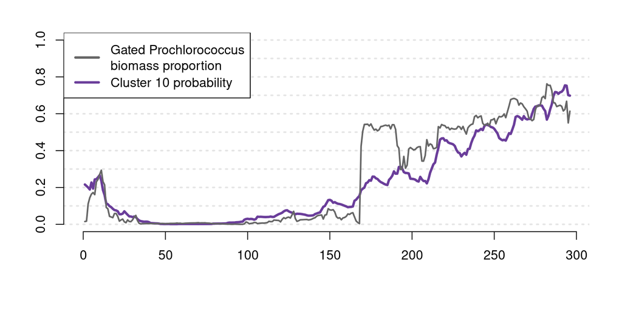

```r
## Make plot
## pdf(file = file.path(figdir, "3d-prochloro-prob.pdf"),
##     width = 8,height = 4)
par(mar = c(5.1, 4.1, 2.1, 2.1))
cols = RColorBrewer::brewer.pal(10, "Paired")
iclusts = c(10)
flowmix::plot_prob(res, iclusts, main = "", cols = cols)
lines(hourly_prop_biomass[-c(1:48)],
      lty = 1, type = 'l',lwd = 2,
      col='grey40')
legend("topleft",
       lwd = c(3, rep(3, length(iclusts))),
       col=c('grey40', cols[iclusts]),
       lty = 1,
       legend=c("Gated Prochlorococcus\nbiomass proportion", paste0("Cluster ", iclusts, " probability")),
       bg="white")
```

```r
## graphics.off()
```

## Figure 14

Figure 14 is produced using this code:

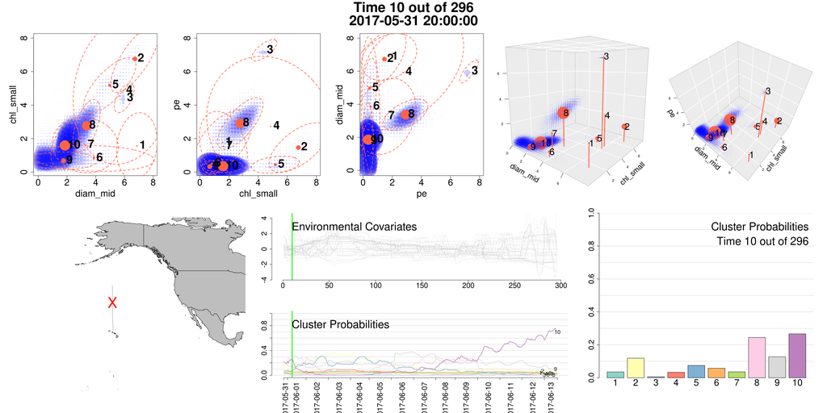

```r
## ## Load 3d model
## cvres_filename = paste0("cvres-", paste0(2,"-", 64,"-", 10), ".Rdata")
## load(file = file.path(datadir, cvres_filename), verbose = FALSE)
## res = cvres$bestres
## class(res) = "flowmix" ## for back-compatibility
## res$prob = res$pie ## for back-compatibility

## ## Load 3d data
## datobj = readRDS(file = file.path(datadir, "MGL1704-hourly-paper.RDS"))
## ylist = datobj$ylist
## countslist = datobj$countslist

tt = 10 ## WHAT is this?
plot_3d(res, ylist, countslist, tt = tt, cex.fac = 10, pt_col = rgb(0,0,1,0.2),
        cex.fac.3d = 0.4,
        lat = datobj$lat,
        lon = datobj$lon)
```